# Varactor analysis of 10X sequenced and Seq-Well sequenced PBMC dataset

## Cell Markers

We use cell markers to identify the clusters. Genes whose names are different from the corresponding CD markers: MS4A1 = CD20, ITGAX = CD11c, IL3RA = CD123, NCAM1 = CD56.

### T cell markers

`r`r FeaturePlot(pbmc, features = c(3E, 3D, 3G), reduction = )

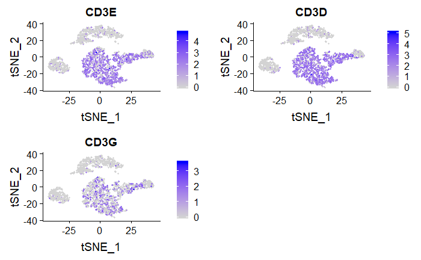

`r`r FeaturePlot(pbmc, features = c(4), reduction = )

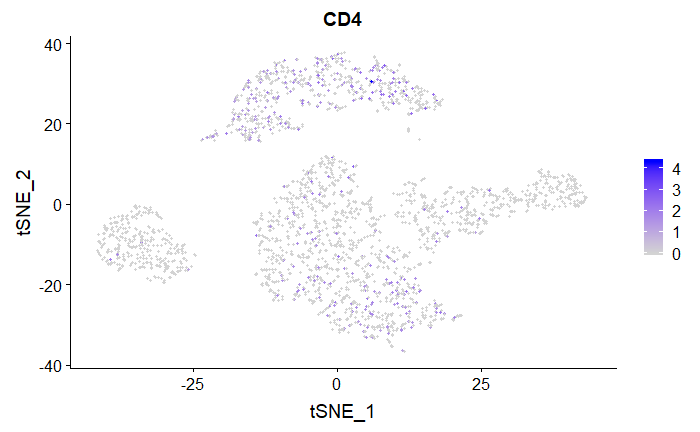

`r`r FeaturePlot(pbmc, features = c(8A, 8B), reduction = )

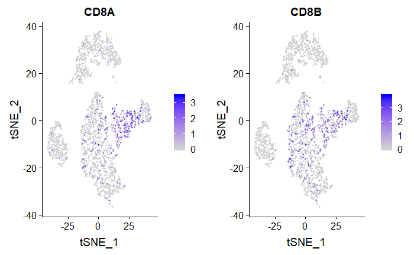

### B cell markers

`r`r FeaturePlot(pbmc, features = c(19, 4A1), reduction = )

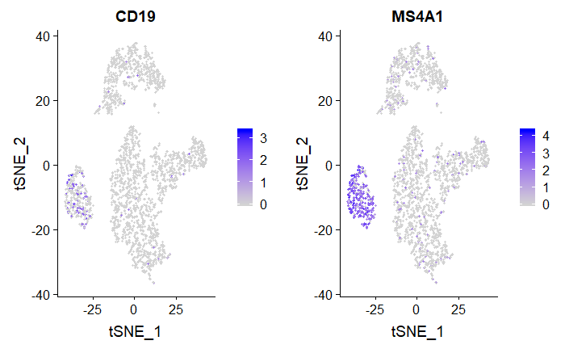

### Dendritic cell markers

`r`r FeaturePlot(pbmc, features = c(, 3RA), reduction = )

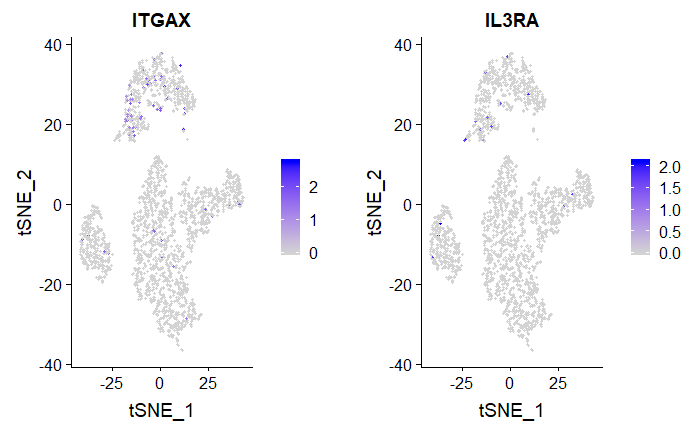

### NK cell markers

`r`r FeaturePlot(pbmc, features = c(1), reduction = )

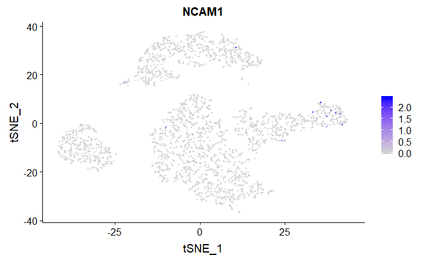

### Monocyte markers

`r`r FeaturePlot(pbmc, slot=‘counts’, features = c(14, 33), reduction = )

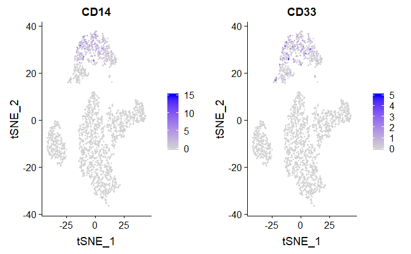

## Overexpressed genes in each cluster

We double check the overexpressed genes in each cluster.

### Cluster 0 - CD4?

`r`r cluster0.markers <- FindMarkers(pbmc, ident.1 = 0, min.pct = 0.25, test.use=, only.pos = T, verbose=FALSE) r cluster0.markers

|  | p_val | avg_logFC | pct.1 | pct.2 | p_val_adj |
| --- | --- | --- | --- | --- | --- |
| LDHB | 8.975114e-238 | 1.1589297 | 0.923 | 0.475 | 2.938273e-233 |
| RPS12 | 3.481987e-225 | 0.5944700 | 1.000 | 0.987 | 1.139933e-220 |
| RPS25 | 8.257177e-205 | 0.6271697 | 0.998 | 0.965 | 2.703235e-200 |
| CD3D | 3.149733e-193 | 1.0542861 | 0.868 | 0.251 | 1.031160e-188 |
| RPS27 | 1.823955e-186 | 0.5426990 | 0.999 | 0.989 | 5.971263e-182 |
| RPS6 | 3.587426e-185 | 0.4876655 | 0.998 | 0.993 | 1.174451e-180 |
| RPS3 | 9.202426e-179 | 0.4812372 | 0.998 | 0.991 | 3.012690e-174 |
| TPT1 | 2.408129e-174 | 0.5392052 | 0.997 | 0.974 | 7.883733e-170 |
| RPS14 | 6.930355e-173 | 0.4626338 | 0.999 | 0.993 | 2.268859e-168 |
| RPL31 | 3.458969e-169 | 0.5795501 | 0.997 | 0.951 | 1.132397e-164 |

[output cut: 149 more lines]

### Cluster 1 - Myeloid?

`r`r cluster1.markers <- FindMarkers(pbmc, ident.1 = 1, min.pct = 0.25, test.use=, only.pos = T, verbose=FALSE) r cluster1.markers

|  | p_val | avg_logFC | pct.1 | pct.2 | p_val_adj |
| --- | --- | --- | --- | --- | --- |
| S100A9 | 0.000000e+00 | 3.8109285 | 0.951 | 0.211 | 0.000000e+00 |
| S100A8 | 0.000000e+00 | 3.7598548 | 0.923 | 0.117 | 0.000000e+00 |
| LGALS2 | 0.000000e+00 | 2.6474131 | 0.872 | 0.051 | 0.000000e+00 |
| FCN1 | 0.000000e+00 | 2.2733449 | 0.908 | 0.143 | 0.000000e+00 |
| CST3 | 1.069820e-296 | 2.2674152 | 0.981 | 0.255 | 3.502375e-292 |
| MS4A6A | 5.289120e-288 | 2.0051461 | 0.665 | 0.034 | 1.731552e-283 |
| TYROBP | 9.940346e-285 | 2.0743204 | 0.972 | 0.256 | 3.254271e-280 |
| CD14 | 1.905193e-278 | 1.8940107 | 0.623 | 0.026 | 6.237222e-274 |
| LYZ | 8.970128e-278 | 3.3130934 | 0.985 | 0.511 | 2.936641e-273 |
| GPX1 | 5.107322e-243 | 2.0172699 | 0.921 | 0.298 | 1.672035e-238 |

[output cut: 339 more lines]

### Cluster 2 - B cell?

`r`r cluster2.markers <- FindMarkers(pbmc, ident.1 = 2, min.pct = 0.25, test.use=, only.pos = T, verbose=FALSE) r cluster2.markers

|  | p_val | avg_logFC | pct.1 | pct.2 | p_val_adj |
| --- | --- | --- | --- | --- | --- |
| CD79A | 0.000000e+00 | 2.9421971 | 0.931 | 0.043 | 0.000000e+00 |
| MS4A1 | 0.000000e+00 | 2.3564604 | 0.854 | 0.053 | 0.000000e+00 |
| TCL1A | 7.216166e-280 | 2.5037876 | 0.625 | 0.021 | 2.362429e-275 |
| LINC00926 | 1.142778e-279 | 1.9723766 | 0.564 | 0.009 | 3.741227e-275 |
| CD79B | 1.796584e-275 | 2.4014015 | 0.911 | 0.143 | 5.881658e-271 |
| HLA-DQA1 | 1.289847e-269 | 2.1283013 | 0.885 | 0.118 | 4.222700e-265 |
| VPREB3 | 3.219977e-241 | 1.6852306 | 0.487 | 0.007 | 1.054156e-236 |
| HLA-DQB1 | 2.656965e-234 | 2.1383218 | 0.862 | 0.146 | 8.698373e-230 |
| CD74 | 3.455793e-189 | 2.0470553 | 1.000 | 0.818 | 1.131358e-184 |
| HLA-DRA | 1.851221e-188 | 1.9264817 | 1.000 | 0.490 | 6.060527e-184 |

[output cut: 112 more lines]

### Cluster 3 - CD8 T?

`r`r cluster3.markers <- FindMarkers(pbmc, ident.1 = 3, min.pct = 0.25, test.use=, only.pos = T, verbose=FALSE) r cluster3.markers

|  | p_val | avg_logFC | pct.1 | pct.2 | p_val_adj |
| --- | --- | --- | --- | --- | --- |
| GZMK | 3.779577e-219 | 2.2536468 | 0.628 | 0.047 | 1.237358e-214 |
| CCL5 | 6.860009e-213 | 2.1411124 | 0.961 | 0.230 | 2.245830e-208 |
| NKG7 | 8.581972e-197 | 1.6656800 | 0.949 | 0.212 | 2.809566e-192 |
| GZMA | 8.552984e-196 | 1.5167269 | 0.813 | 0.115 | 2.800076e-191 |
| CST7 | 9.089226e-183 | 1.4498096 | 0.782 | 0.117 | 2.975631e-178 |
| CTSW | 4.452424e-124 | 1.3904393 | 0.807 | 0.228 | 1.457635e-119 |
| KLRG1 | 1.268389e-115 | 1.2825369 | 0.480 | 0.065 | 4.152451e-111 |
| CD8A | 8.010455e-105 | 1.2868814 | 0.471 | 0.070 | 2.622463e-100 |
| LYAR | 2.677684e-99 | 1.1900829 | 0.583 | 0.129 | 8.766201e-95 |
| B2M | 2.367838e-90 | 0.4835931 | 1.000 | 1.000 | 7.751830e-86 |

[output cut: 129 more lines]

### Cluster 4 - Dendritic?

`r`r cluster4.markers <- FindMarkers(pbmc, ident.1 = 4, min.pct = 0.25, test.use=, only.pos = T, verbose=FALSE) r cluster4.markers

|  | p_val | avg_logFC | pct.1 | pct.2 | p_val_adj |
| --- | --- | --- | --- | --- | --- |
| CDKN1C | 3.675409e-228 | 1.0928139 | 0.506 | 0.008 | 1.203256e-223 |
| HES4 | 3.326757e-209 | 1.2153496 | 0.571 | 0.019 | 1.089114e-204 |
| RP11-290F20.3 | 3.828760e-204 | 1.6298770 | 0.824 | 0.066 | 1.253459e-199 |
| FCGR3A | 1.022453e-191 | 2.2799693 | 0.971 | 0.131 | 3.347306e-187 |
| MS4A7 | 8.162982e-177 | 1.8289913 | 0.771 | 0.073 | 2.672397e-172 |
| CKB | 2.996200e-163 | 0.9076292 | 0.353 | 0.005 | 9.808961e-159 |
| LILRA3 | 7.431743e-157 | 1.1753210 | 0.535 | 0.028 | 2.433004e-152 |
| IFITM3 | 1.358228e-156 | 1.9097190 | 0.982 | 0.171 | 4.446567e-152 |
| LRRC25 | 4.997103e-144 | 1.2878133 | 0.671 | 0.062 | 1.635952e-139 |
| LILRB1 | 9.505149e-132 | 0.9286632 | 0.500 | 0.032 | 3.111796e-127 |

[output cut: 494 more lines]

### Cluster 5 - NK?

`r`r cluster5.markers <- FindMarkers(pbmc, ident.1 = 5, min.pct = 0.25, test.use=, only.pos = T, verbose=FALSE) r cluster5.markers

|  | p_val | avg_logFC | pct.1 | pct.2 | p_val_adj |
| --- | --- | --- | --- | --- | --- |
| GZMB | 2.964632e-264 | 3.3747524 | 0.993 | 0.073 | 9.705611e-260 |
| SPON2 | 4.373034e-244 | 2.3517259 | 0.801 | 0.040 | 1.431644e-239 |
| FGFBP2 | 1.105906e-237 | 2.8520893 | 0.915 | 0.065 | 3.620514e-233 |
| PRF1 | 9.824171e-200 | 2.7688225 | 0.979 | 0.113 | 3.216237e-195 |
| AKR1C3 | 1.082121e-178 | 1.6659016 | 0.489 | 0.014 | 3.542649e-174 |
| CLIC3 | 4.908480e-177 | 1.9663525 | 0.610 | 0.031 | 1.606938e-172 |
| GNLY | 1.052836e-174 | 3.3949206 | 0.965 | 0.136 | 3.446775e-170 |
| KLRD1 | 2.144838e-157 | 1.6071579 | 0.567 | 0.031 | 7.021771e-153 |
| CST7 | 1.384881e-146 | 2.2685743 | 0.965 | 0.156 | 4.533825e-142 |
| CCL4 | 2.143211e-143 | 2.5476119 | 0.752 | 0.079 | 7.016445e-139 |

[output cut: 359 more lines]

`r`r pbmc <- RenameIdents(pbmc, ‘0’=‘CD4’, ‘1’=‘Myeloid’, ‘2’=‘Bcell’, ‘3’=‘CD8’, ‘4’=‘DC’, ‘5’=‘NK’) DimPlot(pbmc, reduction = )

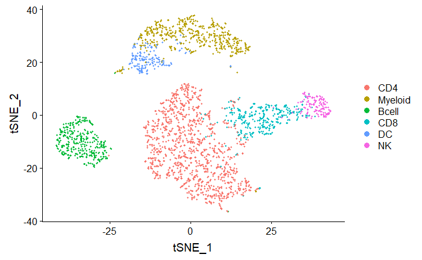

`r`r pbmc_10x = list() pbmc_10x$expr <- as.matrix(pbmc@assays$RNA@data) pbmc_10x$cell_type <- unname(Idents(pbmc))

pbmc_10x$cell_mask <- pbmc_10x$cell_type != ‘DC’ pbmc_10x$expr <- pbmc_10x$expr[, pbmc_10x$cell_mask] pbmc_10x$cell_type <- pbmc_10x$cell_type[pbmc_10x$cell_mask]

`r`r #pbmc_10x$gene_mask <- rowSds(pbmc_10x$expr) > 0.0 #pbmc_10x$expr2 <- pbmc_10x$expr[pbmc_10x$gene_mask, ]

#pbmc_10x$gene_mask <- rowSds(pbmc_10x$expr2) / rowMeans(pbmc_10x$expr2) > 0.5 #pbmc_10x$expr2 <- pbmc_10x$expr2[pbmc_10x$gene_mask, ]

#pbmc_well$mask <- rowSds(pbmc_well$expr) > 0.0 #pbmc_well$expr2 <- pbmc_well$expr[pbmc_well$mask, ]

#pbmc_well$mask <- rowSds(pbmc_well$expr2) / rowMeans(pbmc_well$expr2) > 0.5 #pbmc_well$expr2 <- pbmc_well$expr2[pbmc_well$mask, ]

#gene_common <- intersect(rownames(pbmc_10x$expr2), rownames(pbmc_well$expr2)) #length(rownames(pbmc_10x$expr2)) #length(rownames(pbmc_well$expr2)) #length(gene_common)

#pbmc_10x$expr2 <- pbmc_10x$expr2[gene_common, ] #pbmc_well$expr2 <- pbmc_well$expr2[gene_common, ]

`r`r int <- list()

int$weight <- 1.

`r`r pbmc_10x$sd2 <- rowSds(pbmc_10x$expr2) pbmc_well$sd2 <- rowSds(pbmc_well$expr2)

pbmc_10x$mean2 <- rowMeans(pbmc_10x$expr2) pbmc_well$mean2 <- rowMeans(pbmc_well$expr2)

int$expr <- cbind((pbmc_10x$expr2 - pbmc_10x$mean2) / pbmc_10x$sd2, (pbmc_well$expr2 - pbmc_well$mean2) / pbmc_well$sd2) int$expr <- int$expr * int$weight

int$cell_type <- c(as.character(pbmc_10x$cell_type), pbmc_well$cell_type) int$tech <- c(rep(‘10x’, length(pbmc_10x$cell_type)), rep('well', length(pbmc_well$cell_type)))

`r`r #source(../R/varactor_class.R)

`r`r #obj <- Varactor$new(data = int$expr, labels = list(tech=int$tech, type=int$cell_type), what = ) #obj$reduce(reduce_dim = 50) #obj$reduced <- temp1 #obj$define_metric(name = , type = )

`r`r #obj$measure()

`r`r #obj$embed(name = , type = )

`r`r #obj$plot_embedding(, )

`r`r #temp1 <- obj$reduced

`r`r #obj <- Varactor$new(data = int$expr, labels = list(tech=int$tech, type=int$cell_type), what = )$reduce()

`r`r #obj$define_metric(\primary\, \euclidean\)$measure()$embed(\primary\, \tsne\)$plot_embedding(, , pch=20)

`r`r #obj$define_metric(\alternative\, \davidson\, strata = \tech\)$measure()$embed(\alternative\, \tsne\)$plot_embedding(, , pch=20)

# Jointly analysis using Varactor

## Create a Varactor object

`r`r source(../R/varactor_class.R)

`r`r obj2 <- Varactor$new(data = list(x10x = pbmc_10x$expr, well = pbmc_well$expr), labels = list(x10x = list(type = as.character(pbmc_10x$cell_type)), well = list(type = as.character(pbmc_well$cell_type)) ) )

```
Now you are creating an R6 object.
If you want to make a copy for an R6 object, use 'a_copy <- this_one$clone()'.
```

## Normalize, combine and perform dimensionality reduction

`r`r obj2$normalize()

```
Normalizing data for each dataset...
Note that the nomalization is based all the genes available in each dataset.
```

`r`r obj2$combine()

```
Combine data to one single dataset...
```

`r`r obj2$reduce()

```
Calculating PCA...
Dimensionality is set to 50. If this is not preferred provide a value for parameter reduce.
Depending on the data size, this may take a few minutes...
0 constant genes are not considered in PCA.
```

`r`r #temp_normalized -> obj2$normalized #temp_reduced -> obj2$reduced #temp_combined -> obj2$combined

## UMAP analysis

### Euclidean distance

Coloring: cell types

`r`r obj2$define_metric(\primary\, \euclidean\)$measure()$embed(\primary\, \umap\)$plot_embedding(, , pch=20)

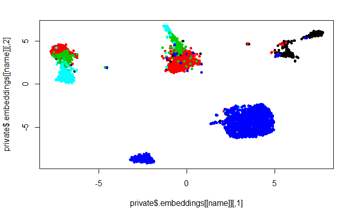

Coloring: sequencing technologies

`r`r obj2$plot_embedding(, , pch=20)

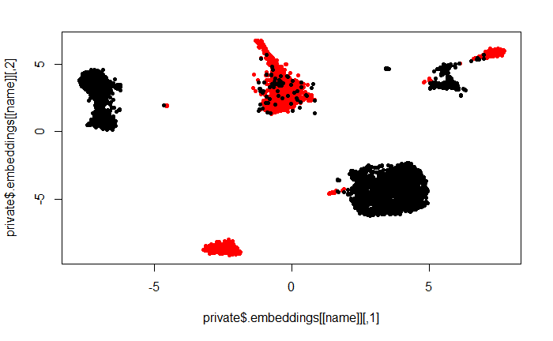

Apparently, difference in technologies are shown heavily in the embedding, hindering our exploration to the biological meanings.

### Davidson distance

We use davidson distance to control the difference introduced by the techonology differences.

`r`r obj2$define_metric(\alternative\, \davidson\, strata = \sample\)$measure()$embed(\alternative\, \umap\)$plot_embedding(, , pch=20)

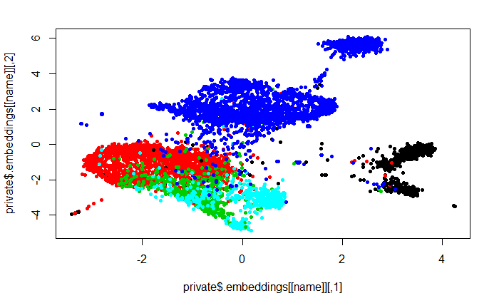

`r`r obj2$plot_embedding(, , pch=20)

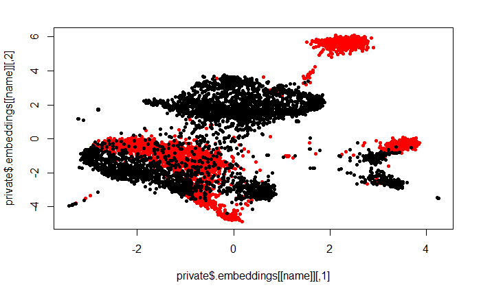

The cell types are more tightly clustered and the difference between the technologies are decreased.

## t-SNE analysis

The same effects also appears in the t-SNE plots.

### Euclidean distance.

`r`r obj2$define_metric(\primary\, \euclidean\)$measure()$embed(\primary\, \tsne\)$plot_embedding(, , pch=20)

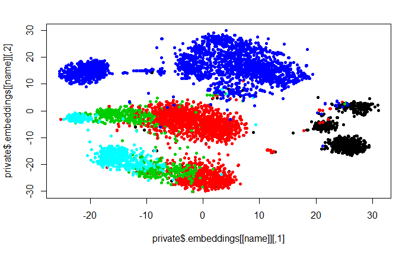

`r`r obj2$plot_embedding(, , pch=20)

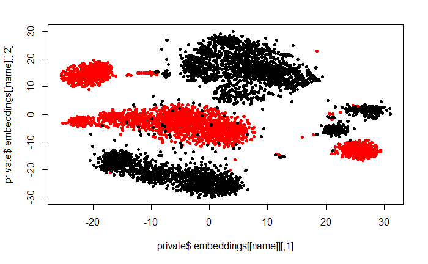

### Davidson distance

`r`r obj2$define_metric(\alternative\, \davidson\, strata = \sample\)$measure()$embed(\alternative\, \tsne\)$plot_embedding(, , pch=20)

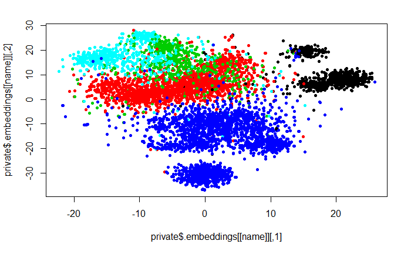

`r`r obj2$plot_embedding(, , pch=20)

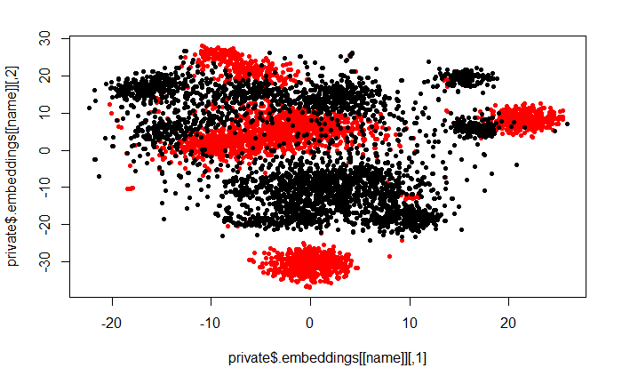